# Part I - (Factors that affect Borrower's Application for Prosper Loan )

## Introduction

### Background Information on Prosper Loan Data

This data set contains 113,937 loans with 81 variables on each loan, including loan amount, borrower rate (or interest rate), current loan status, borrower income, and many others. The column headers is described as follows ListingKey :Unique key for each listing, same value as the 'key' used in the listing object in the API.

ListingNumber:The number that uniquely identifies the listing to the public as displayed on the website.

ListingCreationDate:The date the listing was created.

CreditGrade:The Credit rating that was assigned at the time the listing went live. Applicable for listings pre-2009 period and will only be populated for those listings.

Term:The length of the loan expressed in months.

LoanStatus:The current status of the loan: Cancelled, Chargedoff, Completed, Current, Defaulted, FinalPaymentInProgress, PastDue. The PastDue status will be accompanied by a delinquency bucket.

ClosedDate: Closed date is applicable for Cancelled, Completed, Chargedoff and Defaulted loan statuses.

BorrowerAPR: The Borrower's Annual Percentage Rate (APR) for the loan.

BorrowerRate: The Borrower's interest rate for this loan.

LenderYield: The Lender yield on the loan. Lender yield is equal to the interest rate on the loan less the servicing fee.

EstimatedEffectiveYield: Effective yield is equal to the borrower interest rate (i) minus the servicing fee rate, (ii) minus estimated uncollected interest on charge-offs, (iii) plus estimated collected late fees. Applicable for loans originated after July 2009.

EstimatedLoss: Estimated loss is the estimated principal loss on charge-offs. Applicable for loans originated after July 2009.

EstimatedReturn:The estimated return assigned to the listing at the time it was created. Estimated return is the difference between the Estimated Effective Yield and the Estimated Loss Rate. Applicable for loans originated after July 2009.

ProsperRating (numeric):The Prosper Rating assigned at the time the listing was created: 0 - N/A, 1 - HR, 2 - E, 3 - D, 4 - C, 5 - B, 6 - A, 7 - AA. Applicable for loans originated after July 2009.

ProsperRating (Alpha):The Prosper Rating assigned at the time the listing was created between AA - HR. Applicable for loans originated after July 2009.

ProsperScore: A custom risk score built using historical Prosper data. The score ranges from 1-10, with 10 being the best, or lowest risk score. Applicable for loans originated after July 2009.

ListingCategory: The category of the listing that the borrower selected when posting their listing: 0 - Not Available, 1 - Debt Consolidation, 2 - Home Improvement, 3 - Business, 4 - Personal Loan, 5 - Student Use, 6 - Auto, 7- Other, 8 - Baby&Adoption, 9 - Boat, 10 - Cosmetic Procedure, 11 - Engagement Ring, 12 - Green Loans, 13 - Household Expenses, 14 - Large Purchases, 15 - Medical/Dental, 16 - Motorcycle, 17 - RV, 18 - Taxes, 19 - Vacation, 20 - Wedding Loans

BorrowerState:The two letter abbreviation of the state of the address of the borrower at the time the Listing was created.

Occupation: The Occupation selected by the Borrower at the time they created the listing.

EmploymentStatus:The employment status of the borrower at the time they posted the listing.

EmploymentStatusDuration:The length in months of the employment status at the time the listing was created.

IsBorrowerHomeowner:A Borrower will be classified as a homowner if they have a mortgage on their credit profile or provide documentation confirming they are a homeowner.

CurrentlyInGroup:Specifies whether or not the Borrower was in a group at the time the listing was created.

GroupKey:The Key of the group in which the Borrower is a member of. Value will be null if the borrower does not have a group affiliation.

DateCreditPulled: The date the credit profile was pulled.

CreditScoreRangeLower: The lower value representing the range of the borrower's credit score as provided by a consumer credit rating agency.

CreditScoreRangeUpper:The upper value representing the range of the borrower's credit score as provided by a consumer credit rating agency.

FirstRecordedCreditLine: The date the first credit line was opened.

CurrentCreditLines : Number of current credit lines at the time the credit profile was pulled.

OpenCreditLines: Number of open credit lines at the time the credit profile was pulled.

TotalCreditLinespast7years: Number of credit lines in the past seven years at the time the credit profile was pulled.

OpenRevolvingAccounts: Number of open revolving accounts at the time the credit profile was pulled.

OpenRevolvingMonthlyPayment: Monthly payment on revolving accounts at the time the credit profile was pulled.

InquiriesLast6Months: Number of inquiries in the past six months at the time the credit profile was pulled.

TotalInquiries: Total number of inquiries at the time the credit profile was pulled.

CurrentDelinquencies: Number of accounts delinquent at the time the credit profile was pulled.

AmountDelinquent: Dollars delinquent at the time the credit profile was pulled.

DelinquenciesLast7Years: Number of delinquencies in the past 7 years at the time the credit profile was pulled.

PublicRecordsLast10Years: Number of public records in the past 10 years at the time the credit profile was pulled.

PublicRecordsLast12Months: Number of public records in the past 12 months at the time the credit profile was pulled.

RevolvingCreditBalance: Dollars of revolving credit at the time the credit profile was pulled.

BankcardUtilization: The percentage of available revolving credit that is utilized at the time the credit profile was pulled.

AvailableBankcardCredit: The total available credit via bank card at the time the credit profile was pulled.

TotalTrades: Number of trade lines ever opened at the time the credit profile was pulled.

TradesNeverDelinquent: Number of trades that have never been delinquent at the time the credit profile was pulled.

TradesOpenedLast6Months:Number of trades opened in the last 6 months at the time the credit profile was pulled.

DebtToIncomeRatio: The debt to income ratio of the borrower at the time the credit profile was pulled. This value is Null if the debt to income ratio is not available. This value is capped at 10.01 (any debt to income ratio larger than 1000% will be returned as 1001%).

IncomeRange: The income range of the borrower at the time the listing was created.

IncomeVerifiable: The borrower indicated they have the required documentation to support their income.

StatedMonthlyIncome: The monthly income the borrower stated at the time the listing was created.

LoanKey: Unique key for each loan. This is the same key that is used in the API.

TotalProsperLoans: Number of Prosper loans the borrower at the time they created this listing. This value will be null if the borrower had no prior loans.

TotalProsperPaymentsBilled: Number of on time payments the borrower made on Prosper loans at the time they created this listing. This value will be null if the borrower had no prior loans.

OnTimeProsperPayments: Number of on time payments the borrower had made on Prosper loans at the time they created this listing. This value will be null if the borrower has no prior loans.

ProsperPaymentsLessThanOneMonthLate: Number of payments the borrower made on Prosper loans that were less than one month late at the time they created this listing. This value will be null if the borrower had no prior loans.

ProsperPaymentsOneMonthPlusLate :Number of payments the borrower made on Prosper loans that were greater than one month late at the time they created this listing. This value will be null if the borrower had no prior loans.

ProsperPrincipalBorrowed: Total principal borrowed on Prosper loans at the time the listing was created. This value will be null if the borrower had no prior loans.

ProsperPrincipalOutstanding: Principal outstanding on Prosper loans at the time the listing was created. This value will be null if the borrower had no prior loans.

ScorexChangeAtTimeOfListing: Borrower's credit score change at the time the credit profile was pulled. This will be the change relative to the borrower's last Prosper loan. This value will be null if the borrower had no prior loans.

LoanCurrentDaysDelinquent: The number of days delinquent.

LoanFirstDefaultedCycleNumber: The cycle the loan was charged off. If the loan has not charged off the value will be null.

LoanMonthsSinceOrigination: Number of months since the loan originated.

LoanNumber: Unique numeric value associated with the loan.

LoanOriginalAmount: The origination amount of the loan.

LoanOriginationDate: The date the loan was originated.

LoanOriginationQuarter: The quarter in which the loan was originated.

MemberKey: The unique key that is associated with the borrower. This is the same identifier that is used in the API member object.

MonthlyLoanPayment: The scheduled monthly loan payment.

LP_CustomerPayments: Pre charge-off cumulative gross payments made by the borrower on the loan. If the loan has charged off, this value will exclude any recoveries.

LP_CustomerPrincipalPayments: Pre charge-off cumulative principal payments made by the borrower on the loan. If the loan has charged off, this value will exclude any recoveries.

LP_InterestandFees: Pre charge-off cumulative interest and fees paid by the borrower. If the loan has charged off, this value will exclude any recoveries.

LP_ServiceFees: Cumulative service fees paid by the investors who have invested in the loan.

LP_CollectionFees: Cumulative collection fees paid by the investors who have invested in the loan.

LP_GrossPrincipalLoss: The gross charged off amount of the loan.

LP_NetPrincipalLoss: The principal that remains uncollected after any recoveries.

LP_NonPrincipalRecoverypayments: The interest and fee component of any recovery payments. The current payment policy applies payments in the following order: Fees, interest, principal.

PercentFunded: Percent the listing was funded.

Recommendations: Number of recommendations the borrower had at the time the listing was created.

InvestmentFromFriendsCount: Number of friends that made an investment in the loan.

InvestmentFromFriendsAmount: Dollar amount of investments that were made by friends.

Investors: The number of investors that funded the loan.

## Preliminary Wrangling

```python
# import all packages and set plots to be embedded inline
import numpy as np
import pandas as pd
import matplotlib.pyplot as plt
import seaborn as sb

%matplotlib inline
```

```python
#Let us read the CSV file of prosperLoan Data
df_prosper= pd.read_csv("prosperLoanData.csv")
```

```python
# A quick overview of the shape and composition of the data set is done below
display(df_prosper.shape)
display(df_prosper.dtypes)
display(df_prosper.sample(10))
```

```
(113937, 81)
```

```
ListingKey                      object
ListingNumber                    int64
ListingCreationDate             object
CreditGrade                     object
Term                             int64
                                ...
PercentFunded                  float64
Recommendations                  int64
InvestmentFromFriendsCount       int64
InvestmentFromFriendsAmount    float64
Investors                        int64
Length: 81, dtype: object
```

|  | ListingKey | ListingNumber | ListingCreationDate | CreditGrade | Term | LoanStatus | ClosedDate | BorrowerAPR | BorrowerRate | LenderYield | ... | LP_ServiceFees | LP_CollectionFees | LP_GrossPrincipalLoss | LP_NetPrincipalLoss | LP_NonPrincipalRecoverypayments | PercentFunded | Recommendations | InvestmentFromFriendsCount | InvestmentFromFriendsAmount | Investors |
| --- | --- | --- | --- | --- | --- | --- | --- | --- | --- | --- | --- | --- | --- | --- | --- | --- | --- | --- | --- | --- | --- |
| 51425 | A6CD3591131480628525D52 | 962408 | 2013-10-18 11:44:15.843000000 | NaN | 60 | Current | NaN | 0.21935 | 0.1950 | 0.1850 | ... | -49.79 | 0.00 | 0.00 | 0.00 | 0.0 | 1.0 | 0 | 0 | 0.0 | 1 |
| 9839 | A6ED3374641459430FDB4BA | 68359 | 2006-11-29 22:02:03.997000000 | HR | 36 | Completed | 2007-01-31 00:00:00 | 0.30962 | 0.2900 | 0.2750 | ... | -0.75 | 0.00 | 0.00 | 0.00 | 0.0 | 1.0 | 0 | 0 | 0.0 | 5 |
| 4006 | 67453530467318372EB1846 | 538413 | 2011-11-10 09:41:26.773000000 | NaN | 36 | Completed | 2013-10-01 00:00:00 | 0.29510 | 0.2599 | 0.2499 | ... | -69.34 | 0.00 | 0.00 | 0.00 | 0.0 | 1.0 | 0 | 0 | 0.0 | 55 |
| 72157 | 5F81359573381694937B00B | 1041390 | 2013-11-18 20:01:45.063000000 | NaN | 36 | Current | NaN | 0.33215 | 0.2925 | 0.2825 | ... | -9.91 | 0.00 | 0.00 | 0.00 | 0.0 | 1.0 | 0 | 0 | 0.0 | 1 |
| 33559 | FE833559793742424DD76B9 | 657415 | 2012-10-19 14:19:40.013000000 | NaN | 36 | Current | NaN | 0.26528 | 0.2272 | 0.2172 | ... | -39.17 | 0.00 | 0.00 | 0.00 | 0.0 | 1.0 | 0 | 0 | 0.0 | 54 |
| 17365 | 91E23553501374065976450 | 614933 | 2012-07-21 12:45:19.763000000 | NaN | 60 | Completed | 2013-12-17 00:00:00 | 0.35365 | 0.3258 | 0.3158 | ... | -52.44 | 0.00 | 0.00 | 0.00 | 0.0 | 1.0 | 0 | 0 | 0.0 | 35 |
| 38045 | EE553580872136795DEAD28 | 810780 | 2013-06-16 09:00:47.487000000 | NaN | 60 | Current | NaN | 0.17522 | 0.1519 | 0.1419 | ... | -161.04 | 0.00 | 0.00 | 0.00 | 0.0 | 1.0 | 0 | 0 | 0.0 | 201 |
| 52119 | AFBC35968486199832EAC60 | 1053026 | 2013-12-05 10:12:12.800000000 | NaN | 60 | Current | NaN | 0.17685 | 0.1535 | 0.1435 | ... | -25.34 | 0.00 | 0.00 | 0.00 | 0.0 | 1.0 | 0 | 0 | 0.0 | 1 |
| 36903 | 38FA35925533614227BA8B9 | 962854 | 2013-10-26 01:28:52.387000000 | NaN | 36 | Current | NaN | 0.33215 | 0.2925 | 0.2825 | ... | -25.18 | 0.00 | 0.00 | 0.00 | 0.0 | 1.0 | 0 | 0 | 0.0 | 1 |
| 54546 | A90135368032723943E5177 | 549440 | 2012-01-06 06:17:55.340000000 | NaN | 36 | Chargedoff | 2013-03-15 00:00:00 | 0.28974 | 0.2511 | 0.2411 | ... | -72.46 | -135.38 | 8285.93 | 8285.93 | 0.0 | 1.0 | 0 | 0 | 0.0 | 161 |

10 rows × 81 columns

### What is the structure of your dataset?

There are 113,937 loans with 81 variables on each loan, including loan amount, borrower rate (or interest rate), current loan status, borrower income, and many others. The description of the column headers is done above. Most of the variables in this dataset are numeric in nature. The categorical data in this dataset are Loan Status, Closed Date, Prosper rating(numeric), Prosper rating(Alpha), among a few others

### What is/are the main feature(s) of interest in your dataset?

Three main exploration will be done and they will be in the form of Univariate, bivariate and multivariate analysis to answet the questions below:

**univariate Analysis Questions:**

*Quantitative Analysis:*

What is the distribution of the DebtToIncomeRatio of the borrowers?

What is thedistribution of the OriginalLoanAmount being Borrowed by people ?

What is the distribution of the EmploymentStatusDuration of thye Borrowers?

*Qualitative Analysis:*

Which state do we have the highest borrowers?

What is the distribution of the loanStatus of the borrowers?

What is the distribution of the EmploymentStatus of the borrowers?

What is the distribution of the Income Range of the Borrowers?

What is the distribution of the CreditScoreRange of the Borrowers

**Bivariate Analysis Questions:**

What factors affect the debtToIncomeRatio?

Is Original Loan given out affected by high CreditScore Range Is?

Does employment status affect the amount of Loan being borrowed originally?

What is the relationship between income Range and employment Status?

**Multivariate Analysis Question:**

What effect does original loan amount have on Borrower APR and Borrower Rate?

What is the relationship between StatedMonthlyIncome and BorrowerRate and how does it affectLoanStatus

What is the relationship between employmet status and Stated MonthlyIncome and how does it affect homeownership?

### What features in the dataset do you think will help support your investigation into your feature(s) of interest?

To carry out the explorative analysis, out of the 81 columns, 14 columns that effectively support the questions will be carefully selected amd thoroughly explored. They are: **LoanStatus,BorrowerAPR,BorrowerRate, ProsperRating (numeric), BorrowerState, EmploymentStatus,EmploymentStatusDuration,IsBorrowerHomeowner CreditScoreRangeLower, CreditScoreRangeUpper, DebtToIncomeRatio,IncomeRange,StatedMonthlyIncome,LoanOriginalAmount**

```python
df_prosper.info()
```

```
<class 'pandas.core.frame.DataFrame'>
RangeIndex: 113937 entries, 0 to 113936
Data columns (total 81 columns):
 #   Column                               Non-Null Count   Dtype
---  ------                               --------------   -----
 0   ListingKey                           113937 non-null  object
 1   ListingNumber                        113937 non-null  int64
 2   ListingCreationDate                  113937 non-null  object
 3   CreditGrade                          28953 non-null   object
 4   Term                                 113937 non-null  int64
 5   LoanStatus                           113937 non-null  object
 6   ClosedDate                           55089 non-null   object
 7   BorrowerAPR                          113912 non-null  float64
 8   BorrowerRate                         113937 non-null  float64
 9   LenderYield                          113937 non-null  float64
```

[output cut: 73 more lines]

```python
titles=list(df_prosper.columns)
titles[22],titles[25]=titles[25],titles[22]
```

```python
df_prosper.info()
```

```
<class 'pandas.core.frame.DataFrame'>
RangeIndex: 113937 entries, 0 to 113936
Data columns (total 81 columns):
 #   Column                               Non-Null Count   Dtype
---  ------                               --------------   -----
 0   ListingKey                           113937 non-null  object
 1   ListingNumber                        113937 non-null  int64
 2   ListingCreationDate                  113937 non-null  object
 3   CreditGrade                          28953 non-null   object
 4   Term                                 113937 non-null  int64
 5   LoanStatus                           113937 non-null  object
 6   ClosedDate                           55089 non-null   object
 7   BorrowerAPR                          113912 non-null  float64
 8   BorrowerRate                         113937 non-null  float64
 9   LenderYield                          113937 non-null  float64
```

[output cut: 73 more lines]

```python
#The data set is made up of 81 entries. A total of 29 entries will be selected first for the analysis. The selcted columns will be
#CreditScoreRangeLower ,CreditScoreRangeUpper Income Range, Loan Number,DebtToIncomeRatio ,
# IncomeRange, LoanNumber , LoanOriginalAmount.
titles=list(df_prosper.columns)
titles[22],titles[25]=titles[25],titles[22]
titles[23],titles[26]= titles[26],titles[23]
titles[24],titles[46]= titles[46],titles[24]
titles[25],titles[47]= titles[47],titles[25]
titles[26],titles[49]= titles[49],titles[26]
titles[27],titles[62]= titles[62],titles[27]
titles[28],titles[63]= titles[63],titles[28]
```

```python
# Let us select the initial columns(29) needed fpr the analysis.
df_prosper= df_prosper[titles]
df_prosper_1= df_prosper.iloc[:,:29]
df_prosper_1.info()
```

```
<class 'pandas.core.frame.DataFrame'>
RangeIndex: 113937 entries, 0 to 113936
Data columns (total 29 columns):
 #   Column                     Non-Null Count   Dtype
---  ------                     --------------   -----
 0   ListingKey                 113937 non-null  object
 1   ListingNumber              113937 non-null  int64
 2   ListingCreationDate        113937 non-null  object
 3   CreditGrade                28953 non-null   object
 4   Term                       113937 non-null  int64
 5   LoanStatus                 113937 non-null  object
 6   ClosedDate                 55089 non-null   object
 7   BorrowerAPR                113912 non-null  float64
 8   BorrowerRate               113937 non-null  float64
 9   LenderYield                113937 non-null  float64
```

[output cut: 21 more lines]

```python
#let us further select the 14 columns needed for this Analysis
df_prosper_1.drop(df_prosper_1.columns[[0,1,2,3,4,6,9,10,11,12,14,15,16,18,27]], axis=1, inplace=True)
```

```python
#Check the no of available columns by using the df.info
df_prosper_1.info()
```

```
<class 'pandas.core.frame.DataFrame'>
RangeIndex: 113937 entries, 0 to 113936
Data columns (total 14 columns):
 #   Column                    Non-Null Count   Dtype
---  ------                    --------------   -----
 0   LoanStatus                113937 non-null  object
 1   BorrowerAPR               113912 non-null  float64
 2   BorrowerRate              113937 non-null  float64
 3   ProsperRating (numeric)   84853 non-null   float64
 4   BorrowerState             108422 non-null  object
 5   EmploymentStatus          111682 non-null  object
 6   EmploymentStatusDuration  106312 non-null  float64
 7   IsBorrowerHomeowner       113937 non-null  bool
 8   CreditScoreRangeLower     113346 non-null  float64
 9   CreditScoreRangeUpper     113346 non-null  float64
 10  DebtToIncomeRatio         105383 non-null  float64
 11  IncomeRange               113937 non-null  object
 12  StatedMonthlyIncome       113937 non-null  float64
 13  LoanOriginalAmount        113937 non-null  int64
dtypes: bool(1), float64(8), int64(1), object(4)
memory usage: 11.4+ MB
```

### Now that we have our data set, let the exploratory data analysisn begin!!!

## A quantitative Analysis of the below variables was done to answer the questions below

### Now that we have the questions for the Univarate Exploration. Let us start the analysis!!

### What is the distribution of the DebtToIncomeRatio of the borrowers?

### What is distribution of the OriginalLoanAmount being Borrowed by people ?

### What is the distribution of the EmploymentStatusDuration of thye Borrowers

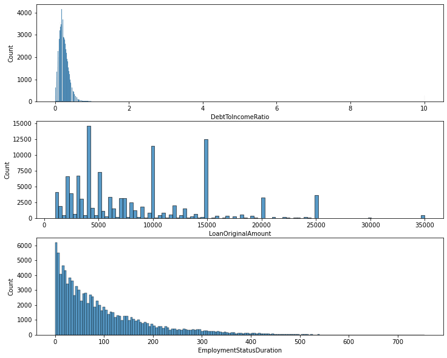

```python
#an histogram will be used as all these are quantitative variables to answer the  the above questions respectively

fig, axes = plt.subplots(nrows=3, figsize = [12,10])
default_color = sb.color_palette()[0]

sb.histplot(data=df_prosper_1, x="DebtToIncomeRatio",color=default_color, ax=axes[0])
sb.histplot(data=df_prosper_1, x="LoanOriginalAmount",color=default_color, ax=axes[1])
sb.histplot(data=df_prosper_1, x="EmploymentStatusDuration",color=default_color, ax=axes[2]);
```

### EmploymentStatusDuration shows a positively skewed data as there is a steady decline of the employment status from beginning of the polot to the end.

```python
#The plot above shows that the distribution is a normal distribution, although it shows a lot of outliers,
#zooming in the plot  will further clarify this
```

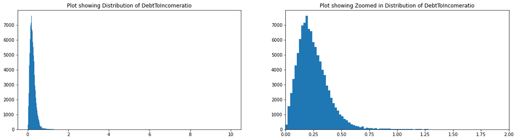

```python
#The plot above shows that the distribution is a normal distribution, although it shows a lot of outliers,
#zooming in the plot  will further clarify this
# the below plot shows the distribution of the DebtToIncomeRatio
plt.figure(figsize=(20, 5))
dir_max = df_prosper['DebtToIncomeRatio'].max()
bins = np.arange(0, dir_max, 0.02)

plt.subplot(1,2,1)
plt.hist(data=df_prosper_1, x='DebtToIncomeRatio', bins=bins);
plt.title("Plot showing Distribution of DebtToIncomeratio")

plt.subplot(1,2,2)
plt.hist(data=df_prosper_1, x='DebtToIncomeRatio', bins=bins)
plt.title("Plot showing Zoomed in Distribution of DebtToIncomeratio");
plt.xlim(0, 2);

# The plot on the right shows this
```

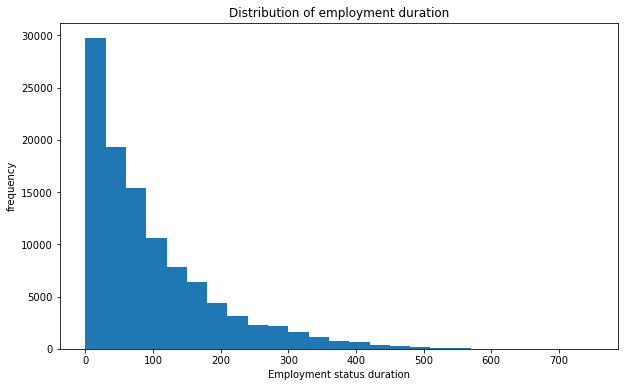

```python
# Employment status duration is a good feature for scalinkk because of the kind of distribution

plt.figure(figsize=(10, 6))
emax = df_prosper_1['EmploymentStatusDuration'].max()
bins = np.arange(0, emax+5, 30)
plt.hist(df_prosper_1['EmploymentStatusDuration'], bins=bins);
plt.xlabel('Employment status duration')
plt.ylabel('frequency')
plt.title('Distribution of employment duration');
```

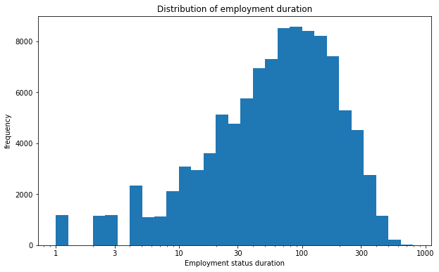

```python
# It can be scaled

# The distribution is skewed towards the left with a long tail at point 0. Let's plot using a log scale instead
plt.figure(figsize=(10, 6))
emax = np.log10(df_prosper_1['EmploymentStatusDuration'].max())
ticks = [1, 3, 10, 30, 100, 300, 1000]
ticks_labels = [f'{x}' for x in ticks]

bins = 10** np.arange(0, emax+0.1, 0.1)
plt.hist(df_prosper_1['EmploymentStatusDuration'], bins=bins)
plt.xscale('log')
plt.xticks(ticks, ticks_labels)
plt.xlabel('Employment status duration')
plt.ylabel('frequency')
plt.title('Distribution of employment duration');
```

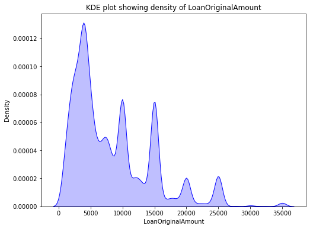

```python
plt.figure(figsize=[8,6])
sb.kdeplot(df_prosper_1['LoanOriginalAmount'], color='b', shade=True);
plt.title("KDE plot showing density of LoanOriginalAmount");
```

## Univariate Exploration: Qualitative Analysis

### What state has the highest borrowers?

### What is the loanStatus of the borrowers?

### What is the EmploymentStatus of the borrowers?

### What is the Income Range of the Borrowers?

### What is the CreditScoreRange of the Borrowers?

```python
# define variable xvar...

def mycountplot(df_prosper_1, xvar):
    #Set plot dimensions:
    plt.figure(figsize=(12,10))
    default_color = sb.color_palette()[0]

    #plot
    sb.countplot(data=df_prosper_1, x=xvar, color= default_color, edgecolor= "black");
    #Add title and format it
    plt.title(f'''Distribution of {xvar}'''.title(), fontsize=14)
    # Add xlabel and format it
    plt.xlabel(xvar.title())
    #Add ylabel and format it
    plt.ylabel("Frequency".title(),fontsize=10)
```

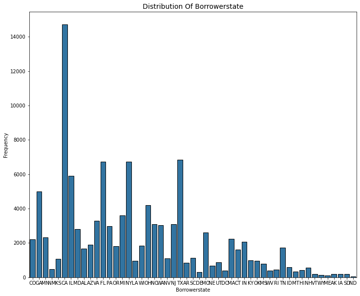

```python
mycountplot(df_prosper_1, "BorrowerState")
```

### From this explorative Analysis we can see that a lot of individuals were borrowing money from the state "CA". We also have a considerable large number of people borrowing from FL,NY,TX.

```python
# convert LoanStatus into ordered categorical types
ordinal_var_dict = {'LoanStatus': ['Completed','Current','FinalPaymentProgress', 'Past Due (1-15 days)', 'Past Due (16-30 days)',
                                   'Past Due (31-60 days)','Past Due (61-90 days)', 'Past Due (91-120 days)',
                                   'Past Due (>120 days)','Cancelled','Defaulted','Chargedoff']}

for var in ordinal_var_dict:
    ordered_var = pd.api.types.CategoricalDtype(ordered = True,
                                                categories = ordinal_var_dict[var])
    df_prosper_1[var] = df_prosper_1[var].astype(ordered_var)
```

```python
df_prosper['IncomeRange'].unique()
```

```
array(['$25,000-49,999', '$50,000-74,999', 'Not displayed', '$100,000+',
       '$75,000-99,999', '$1-24,999', 'Not employed', '$0'], dtype=object)
```

```python
# convert IncomeRange into ordered categorical types
ordinal_var_dict = {"IncomeRange": ["$0", "$1-24,999", "$25,000-49,999", "$50,000-74,999", "$75,000-99,999", "$100,000+"]}

for var in ordinal_var_dict:
    ordered_var = pd.api.types.CategoricalDtype(ordered = True,
                                                categories = ordinal_var_dict[var])
    df_prosper_1[var] = df_prosper_1[var].astype(ordered_var)
```

```python
#Let us create a column that represent the creditscore range by joing CreditScoreRangeLower to CreditScoreUpper
df_prosper_1["CreditScoreRange"]= df_prosper_1["CreditScoreRangeLower"].astype(str) +" - " + df_prosper_1["CreditScoreRangeUpper"].astype(str)
```

```python
#get the unique values of the CreditScoreRange
df_prosper_1["CreditScoreRange"].unique()
```

```
array(['640.0 - 659.0', '680.0 - 699.0', '480.0 - 499.0', '800.0 - 819.0',
       '740.0 - 759.0', '700.0 - 719.0', '820.0 - 839.0', '760.0 - 779.0',
       '660.0 - 679.0', '620.0 - 639.0', '720.0 - 739.0', '520.0 - 539.0',
       '780.0 - 799.0', '600.0 - 619.0', '580.0 - 599.0', '540.0 - 559.0',
       '560.0 - 579.0', '500.0 - 519.0', '840.0 - 859.0', '860.0 - 879.0',
       'nan - nan', '460.0 - 479.0', '0.0 - 19.0', '880.0 - 899.0',
       '440.0 - 459.0', '420.0 - 439.0', '360.0 - 379.0'], dtype=object)
```

```python
#SortValues of the CreditScoreRange
df_prosper_1.sort_values(by=["CreditScoreRange"], ascending = False, inplace= True)
```

```python
# convert CreditScoreRange into ordered categorical types
ordinal_var_dict = {'CreditScoreRange': ['880.0 - 899.0', '860.0 - 879.0', '840.0 - 859.0',
       '820.0 - 839.0', '800.0 - 819.0', '780.0 - 799.0', '760.0 - 779.0',
       '740.0 - 759.0', '720.0 - 739.0', '700.0 - 719.0', '680.0 - 699.0',
       '660.0 - 679.0', '640.0 - 659.0', '620.0 - 639.0', '600.0 - 619.0',
       '580.0 - 599.0', '560.0 - 579.0', '540.0 - 559.0', '520.0 - 539.0',
       '500.0 - 519.0', '480.0 - 499.0', '460.0 - 479.0', '440.0 - 459.0',
       '420.0 - 439.0', '360.0 - 379.0', '0.0 - 19.0']}

for var in ordinal_var_dict:
    ordered_var = pd.api.types.CategoricalDtype(ordered = True,
                                                categories = ordinal_var_dict[var])
    df_prosper_1[var] = df_prosper_1[var].astype(ordered_var)
```

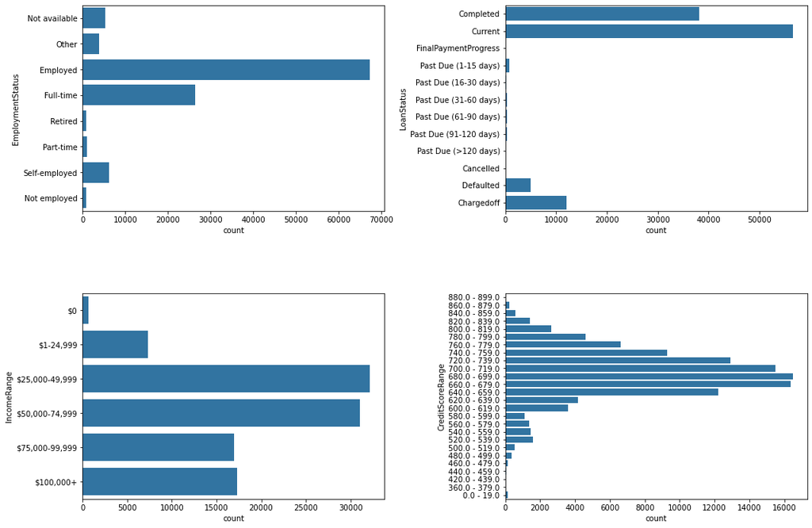

```python
fig, ax = plt.subplots(2,2, figsize = (12,10))

plt.subplots_adjust(left=0.1,bottom=0.1,right=1.2,top=1,wspace=0.4,hspace=0.4)

default_color = sb.color_palette()[0]
sb.countplot(data = df_prosper_1, y = 'EmploymentStatus', color = default_color, ax = ax[0,0])
sb.countplot(data = df_prosper_1, y = 'LoanStatus', color = default_color, ax=ax[0,1])
sb.countplot(data=df_prosper_1, y="IncomeRange", color=default_color, ax=ax[1,0])
sb.countplot(data=df_prosper_1, y='CreditScoreRange', color = default_color, ax=ax[1,1])

plt.show()
```

### From this Analysis we see that, for the Empl0yment status we had a high level of employed individuals. A highest number of individuals considered for loans were employed. A very small number of people given loan were unemployed.

### The LoanStatus with the highest distribution was the current loan status

### A lot of the individuals that were given loan had a high income range between 25,000-49000

# Now that we are done with our Univariate Exploration

## Let us therefore start a bivariate exploration comparing the variables together

```python
numeric_vars = ['DebtToIncomeRatio','LoanOriginalAmount','BorrowerRate','EmploymentStatusDuration', 'StatedMonthlyIncome']
```

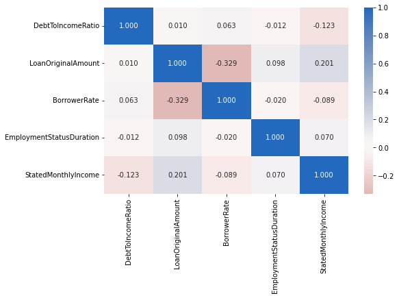

```python
plt.figure(figsize = [8, 5])
sb.heatmap(df_prosper_1[numeric_vars].corr(), annot = True, fmt = '.3f',
           cmap = 'vlag_r', center = 0)
plt.show()
```

### The heat map here shows the correlation between the numeric variables. Darker colors shows stronger correlation while lighter colors

### shows weaker correlation.

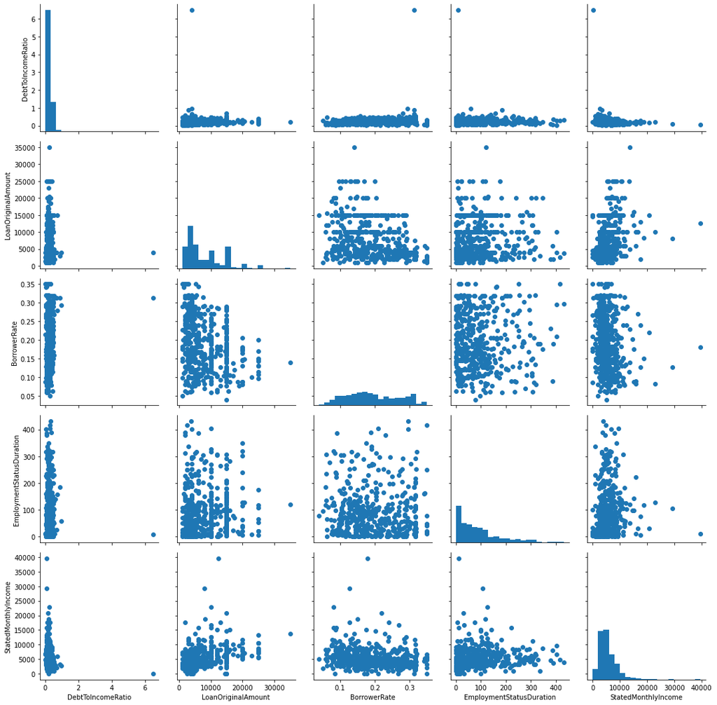

```python
#Let us perform a scatter plot for all Numeric Univariate Variables Selected, i.e for the quantitative analysis

select_numeric_var = df_prosper_1[['DebtToIncomeRatio','LoanOriginalAmount','BorrowerRate','EmploymentStatusDuration', 'StatedMonthlyIncome']]
samples = np.random.choice(df_prosper_1.shape[0], 500, replace = False)
df_prosper_samp = df_prosper_1.loc[samples,:]

g = sb.PairGrid(data = df_prosper_samp, vars = select_numeric_var, height=3)
g = g.map_diag(plt.hist, bins = 20);
g.map_offdiag(plt.scatter)
```

### 1. What factors affect the debtToIncomeRatio?

```python
df_prosper_1.drop(df_prosper_1.index[df_prosper_1['CreditScoreRange'] =="nan-nan"], inplace = True)
```

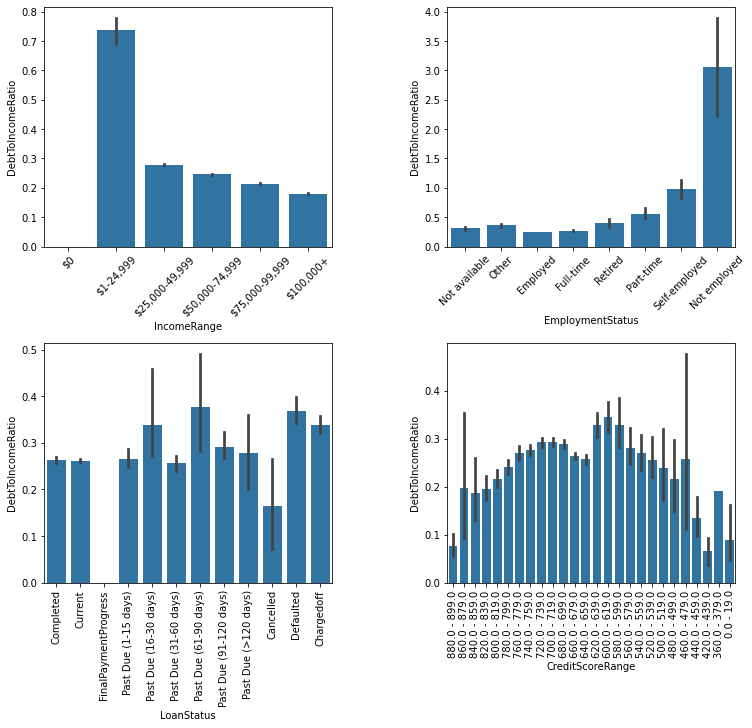

```python
fig, axes = plt.subplots(2,2, figsize=(12,10))
default_color = sb.color_palette()[0]

plt.subplots_adjust(left=0.1,bottom=0.1,right=0.9,top=0.9,wspace=0.4,hspace=0.4)

sb.barplot(data=df_prosper_1, x='IncomeRange', y='DebtToIncomeRatio', color=default_color, ax=axes[0,0])
axes[0,0].tick_params(axis='x', labelrotation=45)


sb.barplot(data=df_prosper_1, x='EmploymentStatus', y='DebtToIncomeRatio', color=default_color, ax=axes[0,1])
axes[0,1].tick_params(axis='x', labelrotation=45)

sb.barplot(data=df_prosper_1, x='LoanStatus', y='DebtToIncomeRatio', color=default_color,ax=axes[1,0])
axes[1,0].tick_params(axis='x', labelrotation=90)

sb.barplot(data=df_prosper_1, x='CreditScoreRange', y='DebtToIncomeRatio', color=default_color,ax=axes[1,1])
axes[1,1].tick_params(axis='x', labelrotation=90);
```

### Looking at the plot of the IncomeRange to DebtToIncomeRation and EmploymentStatus to DebtToIncomeRatio, we see that individuals with high DebtToIncomeRatio were unemployed

### This employment status and IncomeRange strongly affect DebtToIncomeRatio

### Is Original Loan given out affected by high CreditScore Range Is?

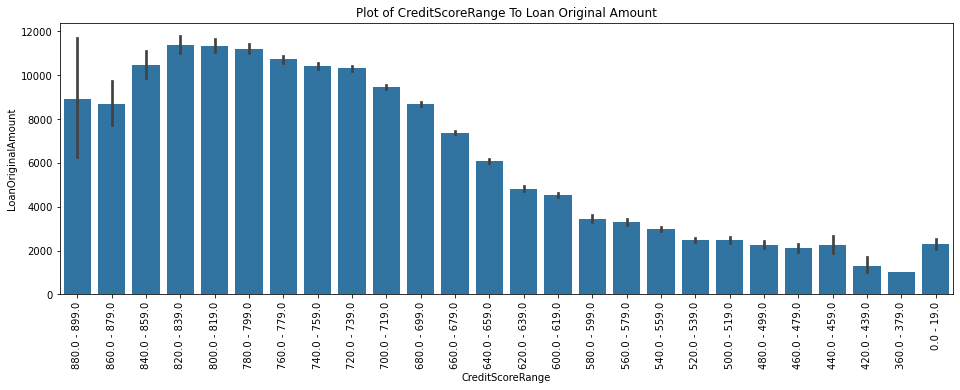

```python
fig, ax = plt.subplots( figsize = (16,5))

default_color = sb.color_palette()[0]

sb.barplot(data=df_prosper_1, x='CreditScoreRange', y='LoanOriginalAmount', color=default_color)
plt.title("Plot of CreditScoreRange To Loan Original Amount")

plt.xticks(rotation=90);
```

### Here we see that creditScoreRange of 800-819, 820-839, were given larger amount of money compared to borrowers with lowerCreditScoreRange.

### It seems a s though that the higher the CreditScore the larger the amount being given.

## Does employment status affect the amount of Loan being borrowed originally?

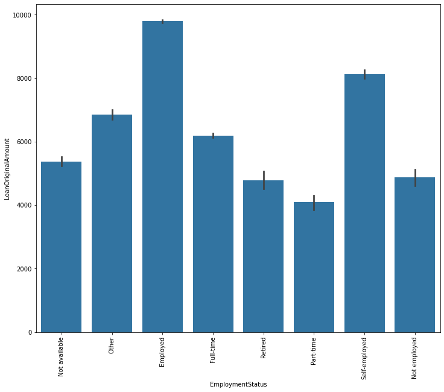

```python
default_color = sb.color_palette()[0]

fig, axes = plt.subplots(figsize=(12,10))

sb.barplot(data=df_prosper_1, x='EmploymentStatus', y='LoanOriginalAmount', color=default_color )

plt.xticks(rotation=90);
```

### From this plot we see truly that employment status affects the amount of Loan being given out, Employed individuals had higher amount being given out followed by self-emplyed individuals

### Thus employment status is a huge factor considered in giving out loan

# Still on Bivariate Exploration, We can answer the following questions with the scatter plot below..

### What is the Relationship between StatedMonthlyIncome and BorrowersRate?

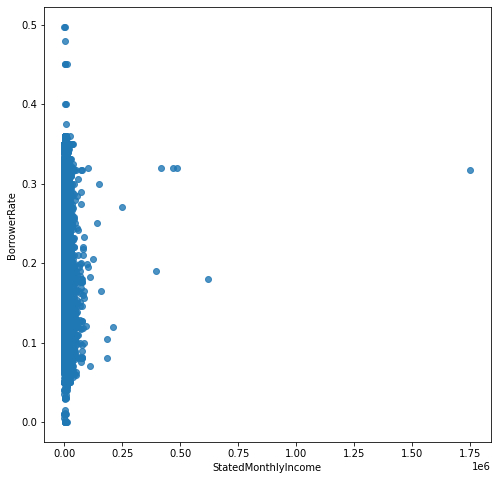

```python
plt.figure(figsize=[8,8])

sb.regplot(data = df_prosper_1, x='StatedMonthlyIncome', y='BorrowerRate', fit_reg= False);
```

## From this plot we can see that there is no correlation between Borrowerate and StatedMonthlyIncome

## Let Us Perform Further Analysis answering the following question;

### Does employment status affect the amount of Loan being borrowed originally?

### Does employment status affect the amount of Loan being borrowed originally?

### What other factora affect EmplymentStatus of Borrowers?

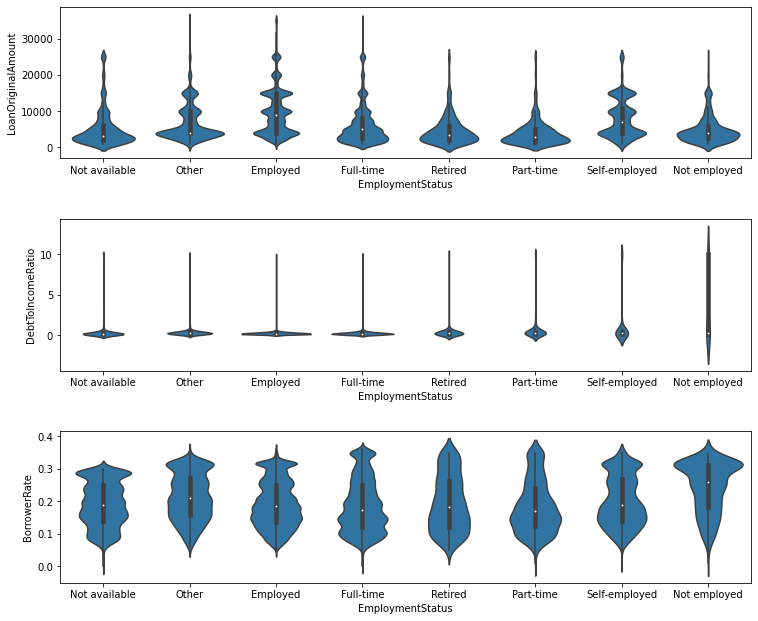

```python
# carry out a violinplot to compare the variables EmploymentStatus and CreditScoreRange
fig, axes = plt.subplots(nrows=3 ,figsize=(12,10))
plt.subplots_adjust(left=0.1,bottom=0.1,right=0.9,top=0.9,wspace=0.4,hspace=0.4)
sb.violinplot(data=df_prosper_1, x='EmploymentStatus', y='LoanOriginalAmount', color=default_color, ax=axes[0])

sb.violinplot(data=df_prosper_1, x='EmploymentStatus', y='DebtToIncomeRatio', color=default_color,ax=axes[1])

sb.violinplot(data=df_prosper_1, x='EmploymentStatus', y='BorrowerRate', color=default_color,ax=axes[2])
```

### Further exploration can be done to answer the above questions with the questions below

### using a boxplot

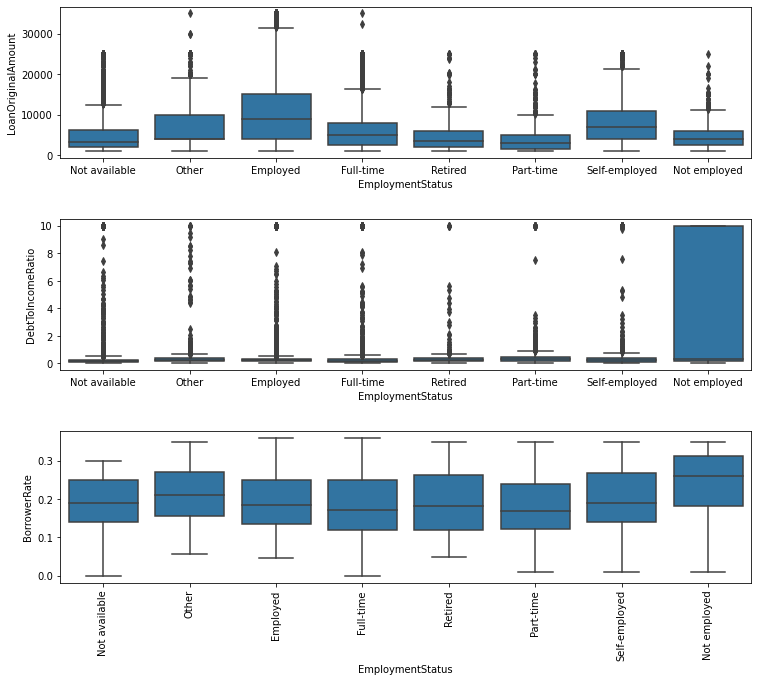

```python
fig, axes = plt.subplots(nrows=3 ,figsize=(12,10))
plt.subplots_adjust(left=0.1,bottom=0.1,right=0.9,top=0.9,wspace=0.4,hspace=0.4)


sb.boxplot(data=df_prosper_1, x='EmploymentStatus', y='LoanOriginalAmount', color=default_color, ax=axes[0])

sb.boxplot(data=df_prosper_1, x='EmploymentStatus', y='DebtToIncomeRatio', color=default_color,ax=axes[1])

sb.boxplot(data=df_prosper_1, x='EmploymentStatus', y='BorrowerRate', color=default_color,ax=axes[2])

plt.xticks(rotation=90);
```

### The Box plot shown here shows more isight into the plot as we can see particularly at the DebtToIncomeratio

### to EmploymentStatus, there are lot of outliers.

## Multivariate Exploration

### Let us start our Multivariate exploration by answering the following questions

### What is the relationship between StatedMonthlyIncome and BorrowerRate and how does it affectLoanStatus

### What ius the relationship between Borrowers rate and LoanOriginalAmount and how does it affect prosperRating (Numeric?

### What is the relationship between employmet status and Stated MonthlyIncome and how does it affect homeownership?

### What is the relationship between StatedMonthlyIncome and BorrowerRate and how does it affectLoanStatus

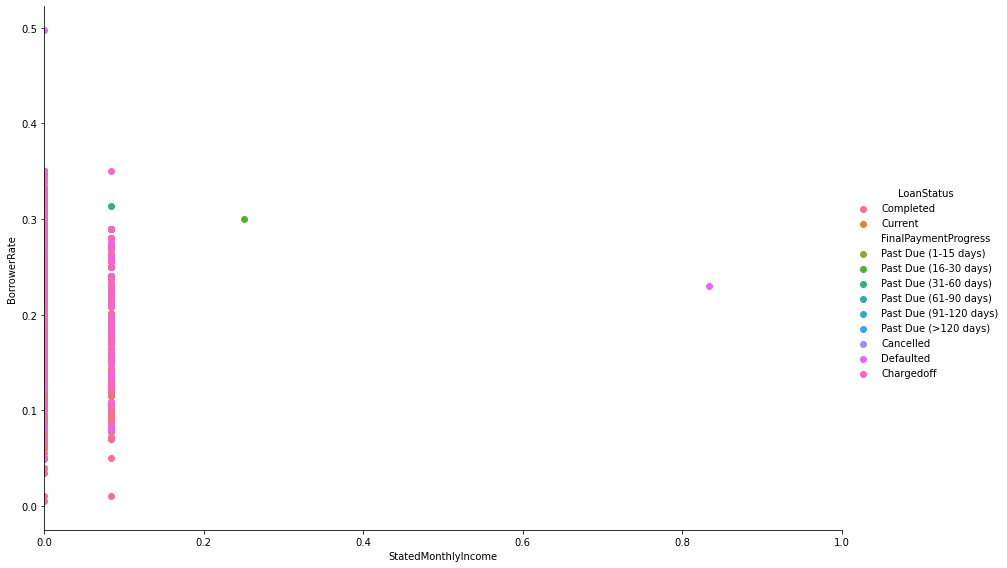

```python
#Carry out  a scatter plot to find out the relationship betwwen StatedMonthlyIncome, Borrowerrate,
# with the third variable being the LoanStatus to find out the relationship between the variables
g = sb.FacetGrid(data = df_prosper_1, hue = 'LoanStatus', height=8, aspect=1.5)
g.map(plt.scatter, 'StatedMonthlyIncome', 'BorrowerRate')
g.add_legend()
plt.xlim(0, 1);
```

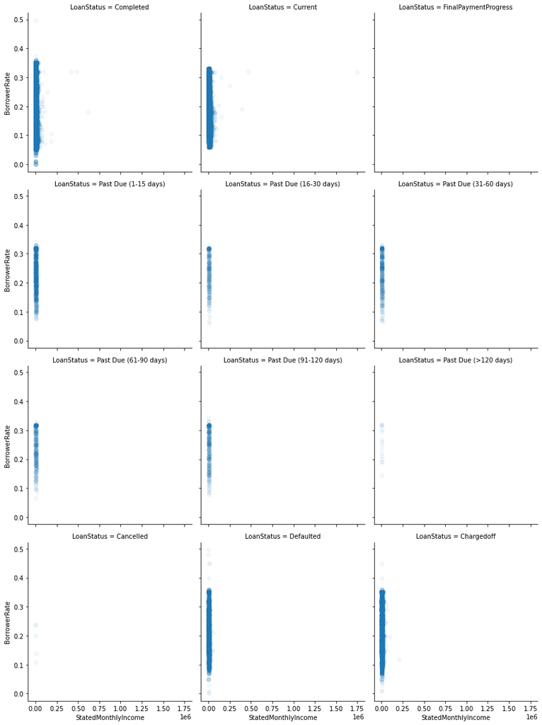

```python
# Let us facet the plot to individually explore the categories of the Loan Status
g = sb.FacetGrid(data = df_prosper_1, col = 'LoanStatus', height=4, col_wrap = 3)
g.map(plt.scatter, 'StatedMonthlyIncome', 'BorrowerRate', alpha=1/20)
```

```python
df_prosper_new= df_prosper_1[df_prosper_1.LoanStatus.isin(['Completed', 'Current','Defaulted'])]
df_prosper_1.head()
```

|  | LoanStatus | BorrowerAPR | BorrowerRate | ProsperRating (numeric) | BorrowerState | EmploymentStatus | EmploymentStatusDuration | IsBorrowerHomeowner | CreditScoreRangeLower | CreditScoreRangeUpper | DebtToIncomeRatio | IncomeRange | StatedMonthlyIncome | LoanOriginalAmount | CreditScoreRange |
| --- | --- | --- | --- | --- | --- | --- | --- | --- | --- | --- | --- | --- | --- | --- | --- |
| 6813 | Completed | 0.18726 | 0.180 | NaN | NaN | NaN | NaN | False | NaN | NaN | 0.16790 | NaN | 3750.000000 | 4000 | NaN |
| 111267 | Completed | 0.22744 | 0.220 | NaN | NaN | NaN | NaN | False | NaN | NaN | 0.21018 | NaN | 3416.666667 | 3800 | NaN |
| 104550 | Completed | 0.15713 | 0.150 | NaN | NaN | NaN | NaN | False | NaN | NaN | 0.08466 | NaN | 5516.333333 | 3001 | NaN |
| 92516 | Completed | NaN | 0.070 | NaN | NaN | NaN | NaN | False | NaN | NaN | 0.04569 | NaN | 12500.000000 | 3500 | NaN |
| 100362 | Completed | 0.10364 | 0.095 | NaN | NaN | NaN | NaN | False | NaN | NaN | 0.15705 | NaN | 10000.000000 | 2000 | NaN |

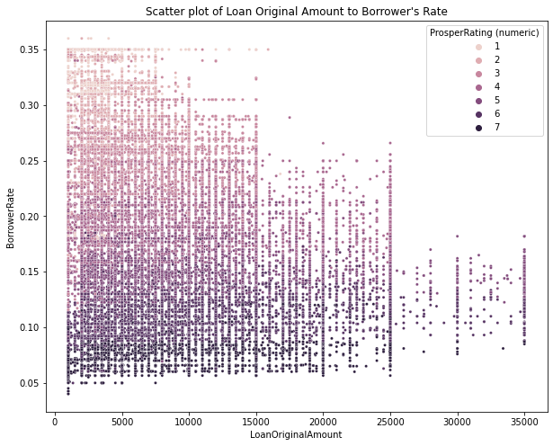

```python
plt.figure(figsize=(10,8))
sb.scatterplot(data=df_prosper, x='LoanOriginalAmount', y='BorrowerRate',hue="ProsperRating (numeric)",
               color = default_color, s=10);
plt.title("Scatter plot of Loan Original Amount to Borrower's Rate")
```

### The higher the borrower rate, the less ther number of individual borrowers and the lower the amount being borrowed

## What is the relationship between employmet status and Stated MonthlyIncome and how does it affect homeownership?

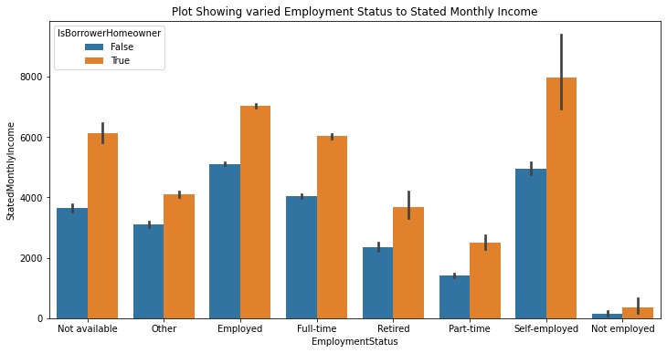

```python
plt.figure(figsize=[12, 6])
sb.barplot(x='EmploymentStatus', y='StatedMonthlyIncome', data=df_prosper_1, hue='IsBorrowerHomeowner');
plt.title("Plot Showing varied Employment Status to Stated Monthly Income");
```

### We also see that the borrowers witht the highest income are selfemployed and are homeowners.